Preliminary data · dupilumab cohort · respiration–cardiac coupling

# Coupled Recovery

In patients regaining their sense of smell on dupilumab, the heart's response to each breath strengthens in proportion to how much olfactory function returns. Smell recovery and respiratory–cardiac coupling appear to recover together.

Patients, pre/post

7

Baseline and ~1 month, full olfactory battery plus continuous respiration and ECG

Showed smell gains

6 / 7

On a composite of discrimination, identification and threshold

Coupling vs olfaction

r = .85

Change in breath-depth drive of HRV against change in olfactory function

Converging measures

4

Independent formulations of the coupling all point the same way

## Rationale

Nasal airflow is not only the vehicle for odorants — it is itself a rhythmic afferent signal that entrains central and autonomic activity. The prediction that follows is direct: if a treatment restores the nasal sensory pathway, the breath-locked drive on downstream physiology should strengthen alongside it.

Dupilumab offers an unusually clean test. Every treated patient experiences polyp reduction and improved nasal patency, but olfactory recovery varies widely and is not predicted by the airway change. Airway mechanics are therefore roughly held constant across patients while sensory restoration varies — so a physiological measure that tracks *olfactory* outcome specifically, rather than tracking everyone equally, is informative about the sensory pathway rather than the plumbing.

## The premise holds: recovery is large and highly variable

Patients enter at or near the floor and diverge sharply. That variability is the whole basis for the analysis — it is what allows a physiological measure to be tested against outcome rather than against time on drug.

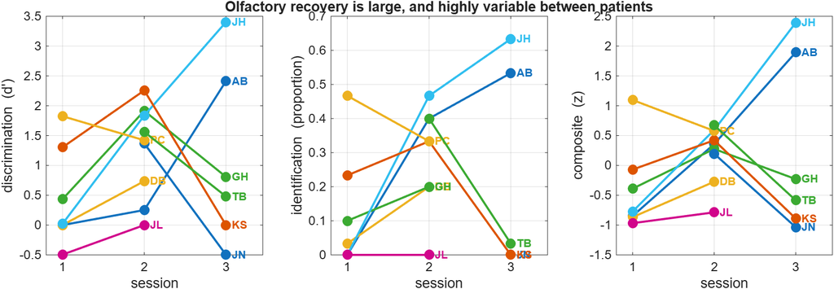

Figure 1 · **Olfactory recovery across sessions.** Most patients begin at or near floor on discrimination and identification. By one month the spread is substantial, and by six months trajectories diverge further — some continuing to improve, others falling back. Composite is the mean of z-scored discrimination, identification and air-calibrated threshold.

## Cardiac coupling recovers in step with it

For each session we measured, breath by breath, how much the heart period swings within a breath, and related it to the size of that breath. Two quantities follow. The first is how much cardiac modulation a breath of *fixed* size produces — a level. The second is how much *extra* modulation a deeper breath produces — a gain. Both track olfactory change.

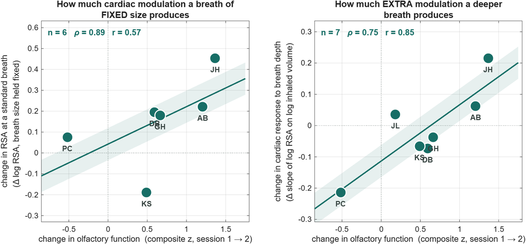

Why this is not simply "more HRV"

General measures of heart-rate variability — beat-to-beat interval variability and its robust and threshold-based variants — do *not* track olfactory recovery in this cohort. What tracks it is specifically the coupling between breathing and the heart. The effect is also not explained by changes in heart rate or in breathing rate, both of which are near zero against olfactory change.

## A mechanistic hint: the response shifts from time to volume

Breath duration and breath depth move in opposite directions. In patients who recovered more smell, the cardiac response became *more* sensitive to how much air moved and *less* sensitive to how long the breath lasted.

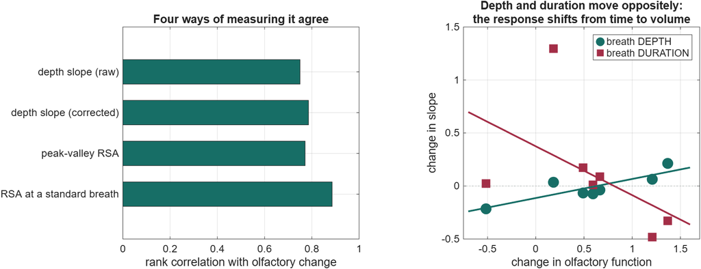

Figure 3 · **Convergence, and a dissociation.** Left: four independent formulations of respiratory–cardiac coupling agree in direction and magnitude. Right: depth sensitivity rises with recovery while duration sensitivity falls — the cardiac response reallocates from time-driven to volume-driven.

This is what tighter breath-locking looks like. If the cardiac oscillation becomes firmly entrained to the breath cycle, each breath carries one rise-and-fall regardless of its duration, so duration stops buying extra modulation — while the amplitude of that single locked cycle continues to scale with respiratory drive. One change in entrainment produces both halves of the pattern.

It is also what one would predict from the afferent side. Pulmonary stretch receptors and nasal flow-sensitive afferents signal *volume*, not elapsed time. A stronger, more reliable per-breath afferent signal should make the autonomic response more volume-graded and more tightly phase-locked — which is precisely the shift observed.

## The effect appears against the most peripheral measure

The threshold task yields a bias-calibrated index of intensity sensitivity. Each odor concentration is rated against a blank-air trial in the same session, so subtracting air removes both the rating offset and any individual response bias, leaving (high − air) and (med − air) as sensitivity contrasts on a common footing. Of the two, the high concentration carries the usable dynamic range; the medium sits near floor for most patients.

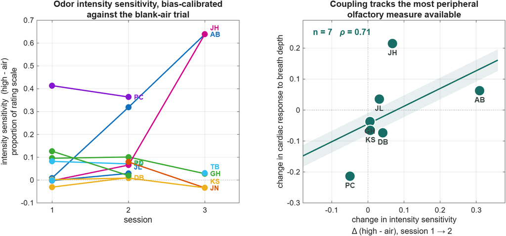

Figure 4 · **Odor intensity sensitivity and cardiac coupling.** Left: most patients cannot distinguish odor from blank air at baseline; two recover sharply. Right: change in the cardiac response to breath depth tracks change in intensity sensitivity (ρ = 0.71), as strongly as it tracks the full three-task composite.

Why this measure in particular

Identification requires naming and semantic access; discrimination requires a comparison judgment. Rating how intense an odor smells is the closest available readout of transduction at the epithelium. If restored nasal sensory function is what strengthens breath-locked afferent drive, the intensity measure is where the relationship should appear — and it does, undiluted.

## What the proposed work would establish

These are seven patients and a descriptive relationship. They are sufficient to show the measures are obtainable, the variance is there to exploit, and the predicted direction is the one observed. The proposed work would test it properly.

- **Power the primary test.** A single pre-specified coupling measure in a cohort several times this size, with the analysis fixed in advance rather than selected from a panel.
- **Separate the sensory account from the inflammatory one.** Systemic inflammation plausibly affects olfactory epithelium and autonomic function independently. Adding inflammatory markers and testing whether coupling tracks olfactory outcome after adjusting for them distinguishes a shared systemic factor from a breathing-specific mechanism.
- **Test the nasal-route prediction directly.** If the effect depends on nasal afferent drive, it should attenuate during oral breathing. This is a within-patient contrast and the strongest available discriminator.
- **Extend the time course.** The relationship is clearest over the first month. Whether coupling tracks olfaction over six months, where trajectories diverge and some patients lose ground, is a separate and clinically interesting question.
- **Standardise acquisition.** A brief seated spontaneous-breathing block in every session would substantially improve the precision of every coupling measure at negligible cost.